# HW10

Xuan Wen Loo

2024-04-10

## Problem 1

```
##
## Call:
## glm(formula = Direction ~ Lag1 + Lag2 + Lag3 + Lag4 + Lag5 +
##     Volume, family = "binomial", data = Weekly)
##
## Deviance Residuals:
##     Min       1Q   Median       3Q      Max
## -1.6949  -1.2565   0.9913   1.0849   1.4579
##
## Coefficients:
##             Estimate Std. Error z value Pr(>|z|)
## (Intercept)  0.26686    0.08593   3.106   0.0019 **
## Lag1        -0.04127    0.02641  -1.563   0.1181
## Lag2         0.05844    0.02686   2.175   0.0296 *
## Lag3        -0.01606    0.02666  -0.602   0.5469
## Lag4        -0.02779    0.02646  -1.050   0.2937
## Lag5        -0.01447    0.02638  -0.549   0.5833
## Volume      -0.02274    0.03690  -0.616   0.5377
## ---
## Signif. codes:  0 '***' 0.001 '**' 0.01 '*' 0.05 '.' 0.1 ' ' 1
##
## (Dispersion parameter for binomial family taken to be 1)
##
##     Null deviance: 1496.2  on 1088  degrees of freedom
## Residual deviance: 1486.4  on 1082  degrees of freedom
## AIC: 1500.4
##
## Number of Fisher Scoring iterations: 4
```

```
##
## full.pred Down  Up
##      Down   54  48
##      Up    430 557
```

```
## [1] 0.4389348
```

```
##
## Call:
## glm(formula = Direction ~ Lag2, family = "binomial", data = train_data)
##
## Deviance Residuals:
##    Min      1Q  Median      3Q     Max
## -1.536  -1.264   1.021   1.091   1.368
##
## Coefficients:
##             Estimate Std. Error z value Pr(>|z|)
## (Intercept)  0.20326    0.06428   3.162  0.00157 **
## Lag2         0.05810    0.02870   2.024  0.04298 *
## ---
## Signif. codes:  0 '***' 0.001 '**' 0.01 '*' 0.05 '.' 0.1 ' ' 1
##
## (Dispersion parameter for binomial family taken to be 1)
##
##     Null deviance: 1354.7  on 984  degrees of freedom
## Residual deviance: 1350.5  on 983  degrees of freedom
## AIC: 1354.5
##
## Number of Fisher Scoring iterations: 4
```

```
##
## test.pred Down Up
##      Down    9  5
##      Up     34 56
```

```
## [1] 0.375
```

```
## Call:
## lda(Direction ~ Lag2, data = train_data)
##
## Prior probabilities of groups:
##      Down        Up
## 0.4477157 0.5522843
##
## Group means:
##             Lag2
## Down -0.03568254
## Up    0.26036581
##
## Coefficients of linear discriminants:
##            LD1
## Lag2 0.4414162
```

```
##
## lda.class Down Up
##      Down    9  5
##      Up     34 56
```

```
## [1] 0.375
```

```
##
##        Down Up
##   Down    0  0
##   Up     43 61
```

```
## [1] 0.5865385
```

```
##
## nb.class Down Up
##     Down    0  0
##     Up     43 61
```

```
## [1] 0.5865385
```

## Problem 2

```
##
## Call:  glm(formula = chd ~ age, family = "binomial", data = heart)
##
## Coefficients:
## (Intercept)          age
##    -3.52171      0.06411
##
## Degrees of Freedom: 461 Total (i.e. Null);  460 Residual
## Null Deviance:       596.1
## Residual Deviance: 525.6     AIC: 529.6
```

```
##         1
## 0.4215756
```

```
## [1] 0.02701954
```

## Problem 3

Linear discriminant function (training set):  
$d_0(X_1) = X_1 * (3.4/4) - (3.4^2/2*4) + log(0.32)$  
$d_1(X_1) = X_1 * (5.1/4) - (5.1^2/2*4) + log(0.68)$

Linear discriminant function (test set):  
$d_0(X_1) = X_1 * (3.2/4.5) - (3.2^2/2*4.5) + log(0.35)$  
$d_1(X_1) = X_1 * (5.5/4.5) - (5.5^2/2*4.5) + log(0.65)$

Based on the function of the test set, if $d_0(X_1)$ gives a higher value than $d_1(X_1)$, then the test observation will be assigned to Y=0. Otherwise if $d_1(X_1) > d_0(X_1)$, the test observation will be assigned to Y=1.

## Problem 4

#(Refer to ‘HW10(Q4-5).R’ for Problem 4 and 5 codes)

1. [1] 0.08000845 0.08533290 0.08335070 0.09066961  
   Optimal K: 1  
   knn.pred  
   testY 0 1 2 3 4 5 6 7 8 9  
   0 7 0 0 0 0 0 0 0 0 0  
   1 0 7 0 0 0 0 0 0 0 0  
   2 0 0 7 0 0 0 0 0 0 0  
   3 0 0 0 12 0 0 0 0 0 0  
   4 0 0 0 0 13 0 0 0 0 2  
   5 0 0 0 0 0 10 0 0 0 0  
   6 0 0 0 0 0 0 9 0 0 0  
   7 0 0 0 0 1 0 0 5 0 0  
   8 0 0 0 1 0 2 0 1 10 0  
   9 1 0 0 0 2 0 0 0 0 10  
   [1] 0.1
2. The error that shows from performing lda is that some variables appear to be constant within groups. Those columns of train$x have a single value, in this case all 0’s, so they do not provide any discriminatory information for classification.
3. The dataset, consisting of handwritten digit images, have complex decision boundaries that cannot be well approximated by linear methods as shown in LDA. KNN, being a non-parametric method, does not make assumptions about the underlying data distribution and can capture complex decision boundaries. KNN can perform well in high-dimensional spaces, as it relies on distance metrics to find nearest neighbors.

## Problem 5

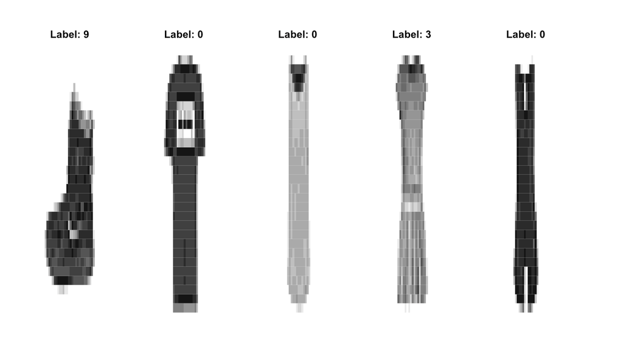

2. [1] 0.2130025 0.1986714 0.1990069 0.1983458  
   Optimal K: 9  
   knn.pred  
   testY 0 1 2 3 4 5 6 7 8 9  
   0 3 0 0 0 0 0 0 0 0 0  
   1 0 8 0 0 1 0 0 0 0 0  
   2 1 0 10 0 1 0 2 0 0 0  
   3 0 0 0 7 2 0 0 0 0 0  
   4 1 0 2 0 8 0 1 0 0 0  
   5 0 0 0 0 0 5 0 2 0 2  
   6 2 0 1 0 1 0 3 0 0 0  
   7 0 0 0 0 0 0 0 14 0 0  
   8 0 0 1 0 0 0 1 0 7 0  
   9 0 0 0 0 0 0 0 0 0 14  
   [1] 0.21